# Multi-Class Classification Model for [Project Name] Using R version 12

### 2.b) Data visualizations

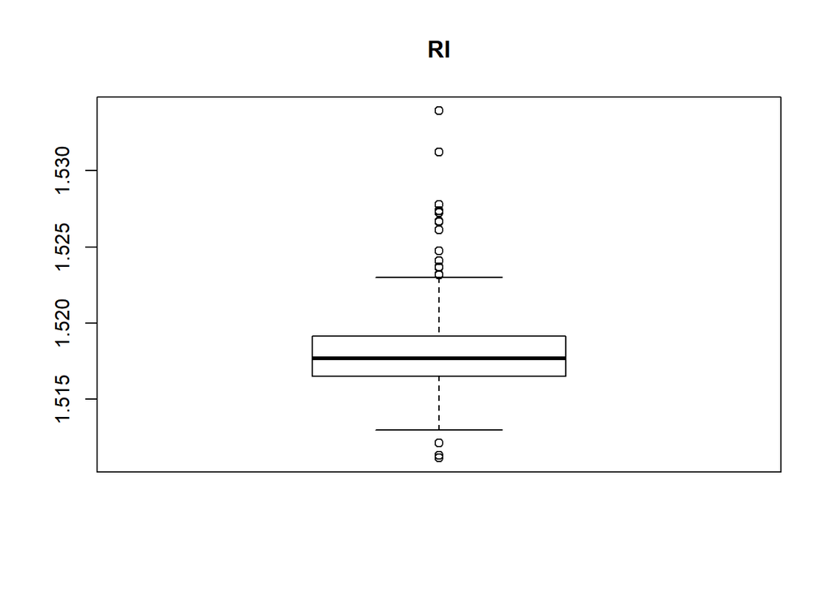

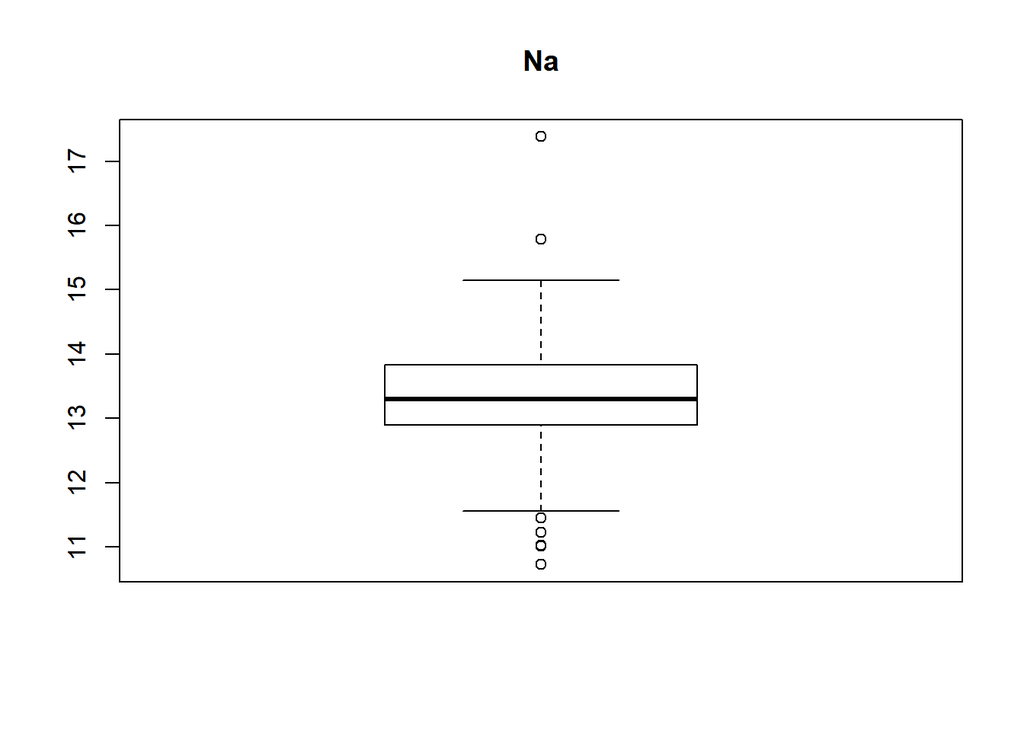

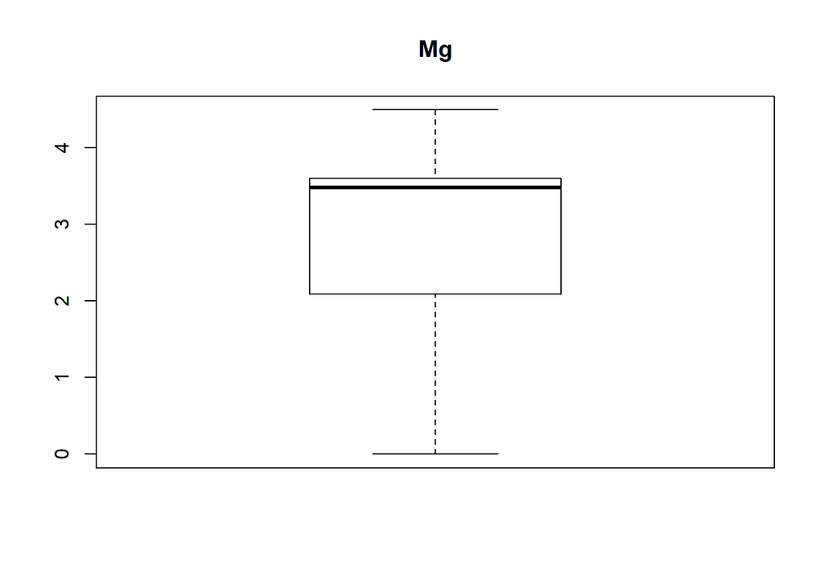

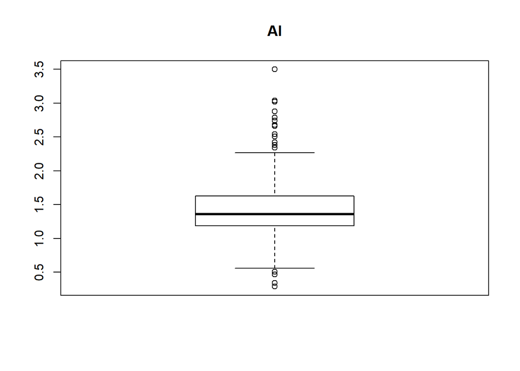

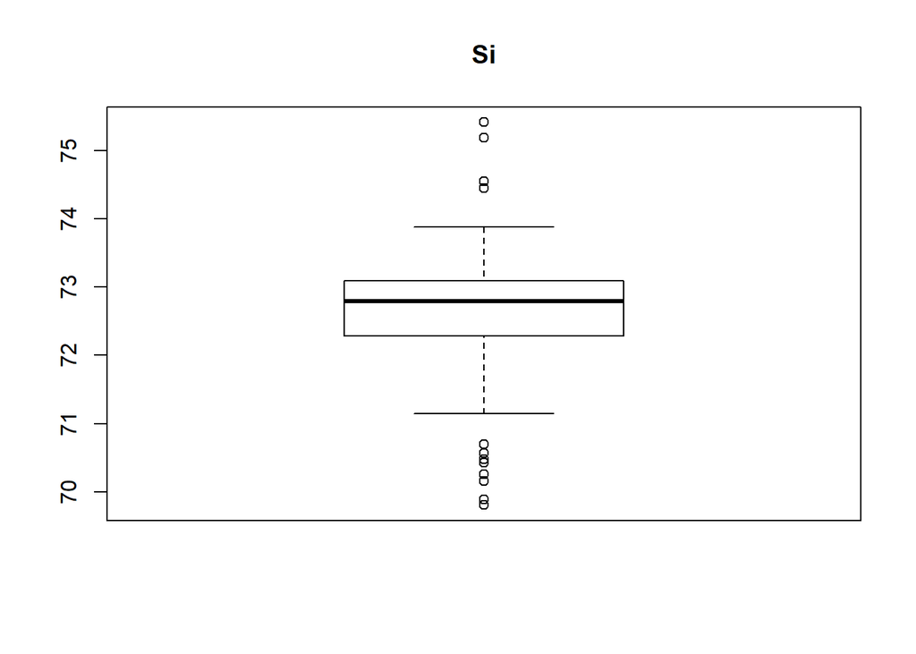

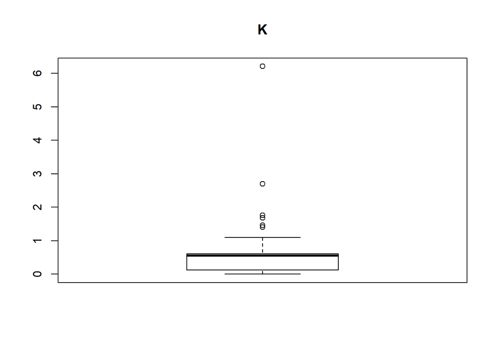

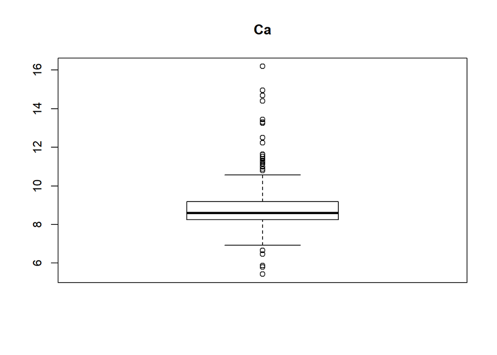

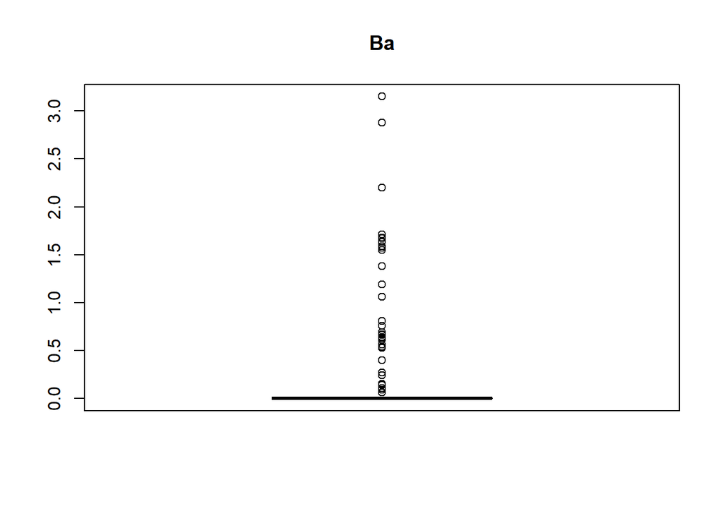

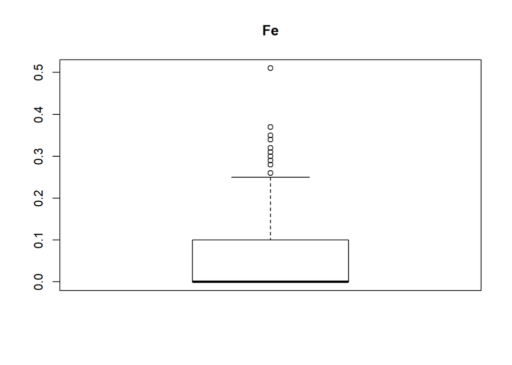

```r
# Boxplots for each attribute
# par(mfrow=c(dispRow,dispCol))
for(i in 1:totAttr) {
    boxplot(X_original[,i], main=names(X_original)[i])
}
```

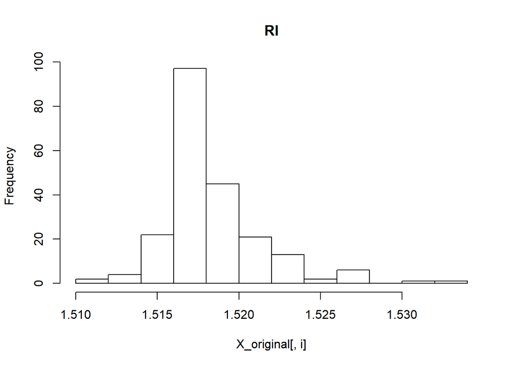

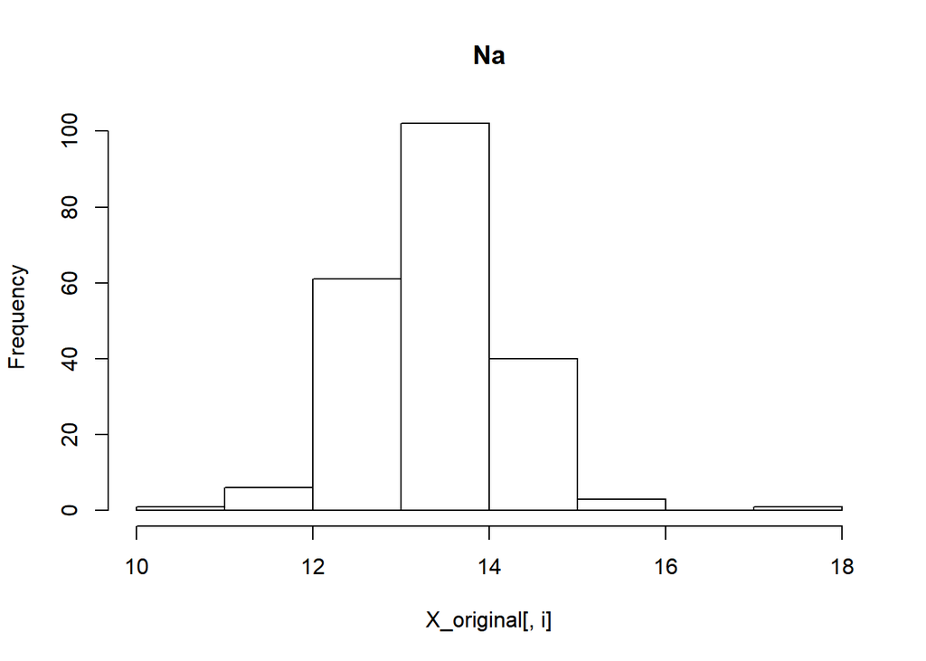

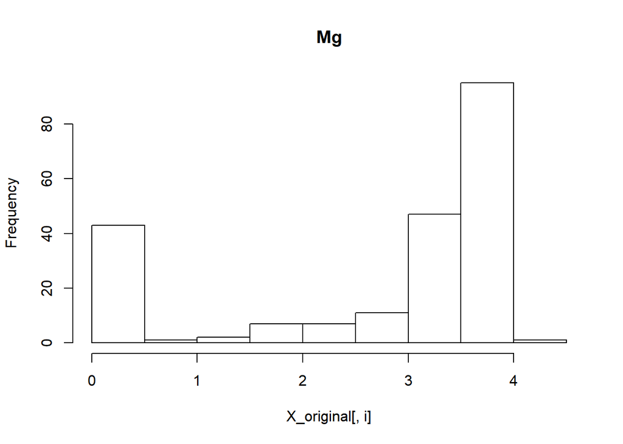

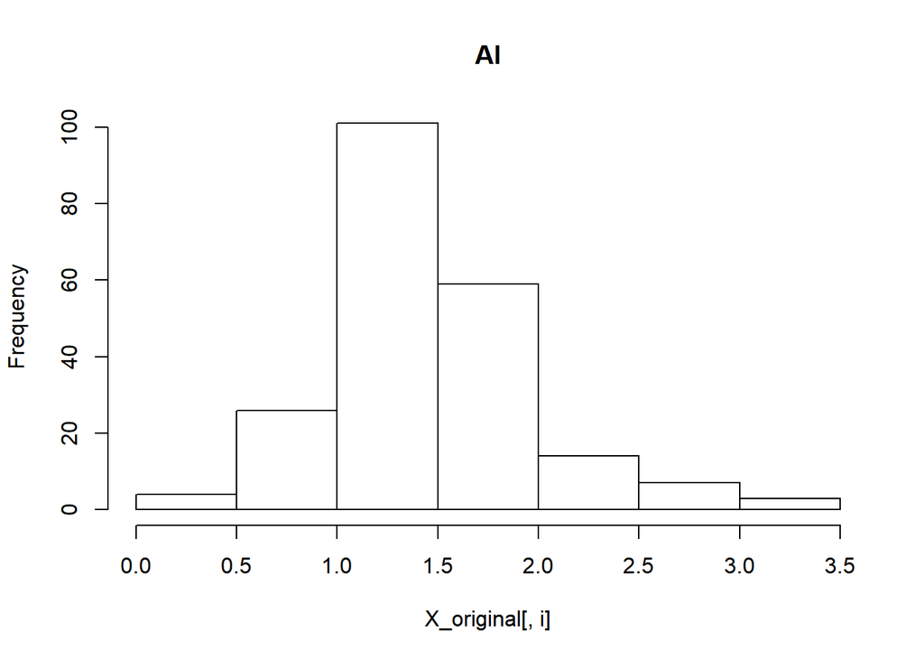

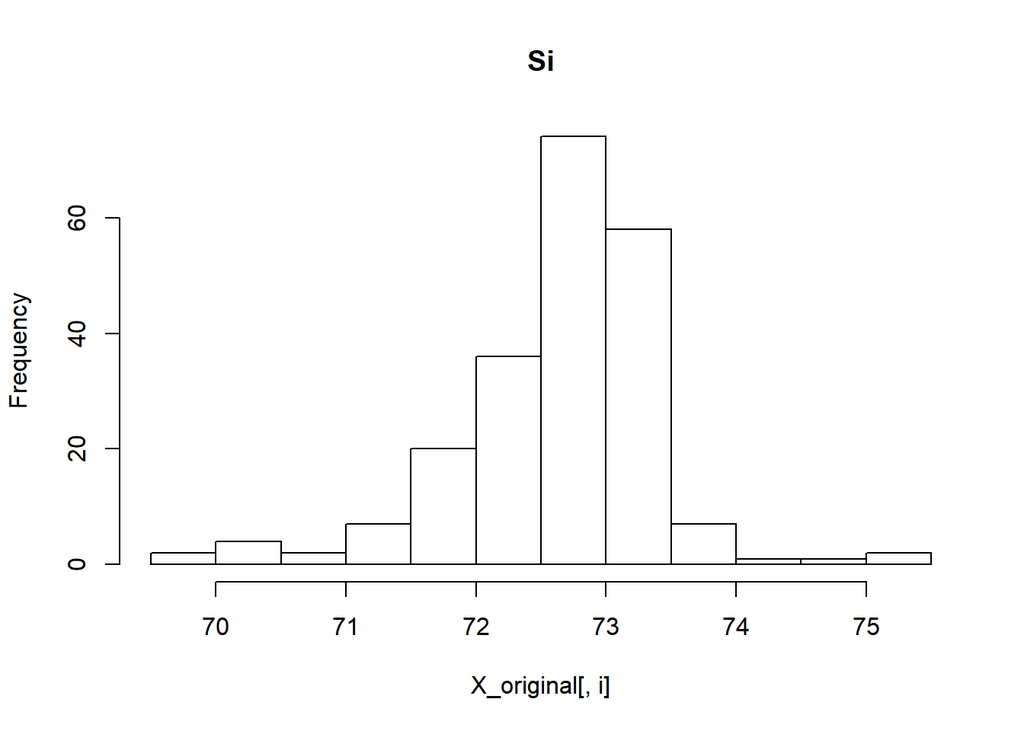

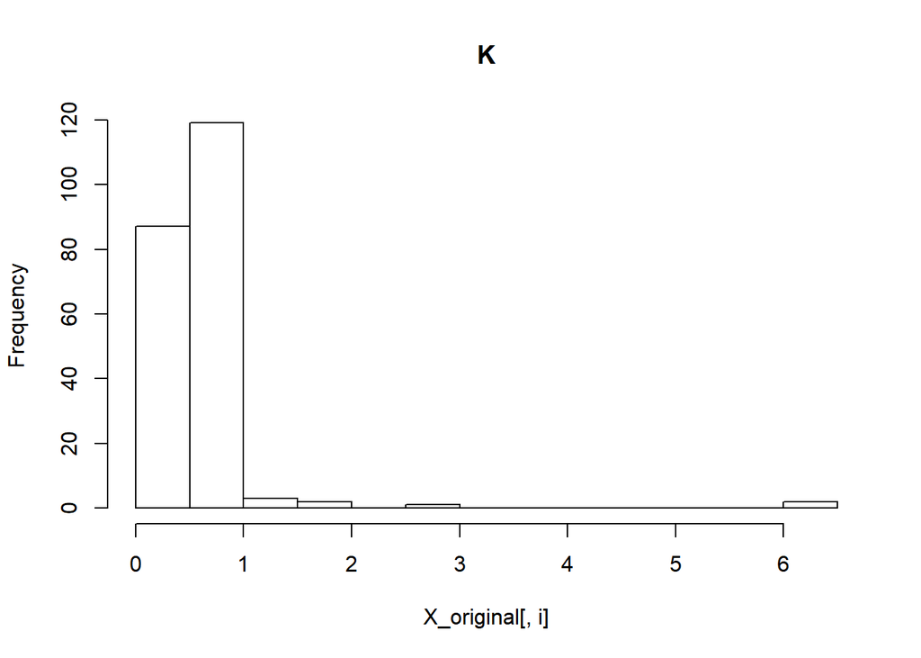

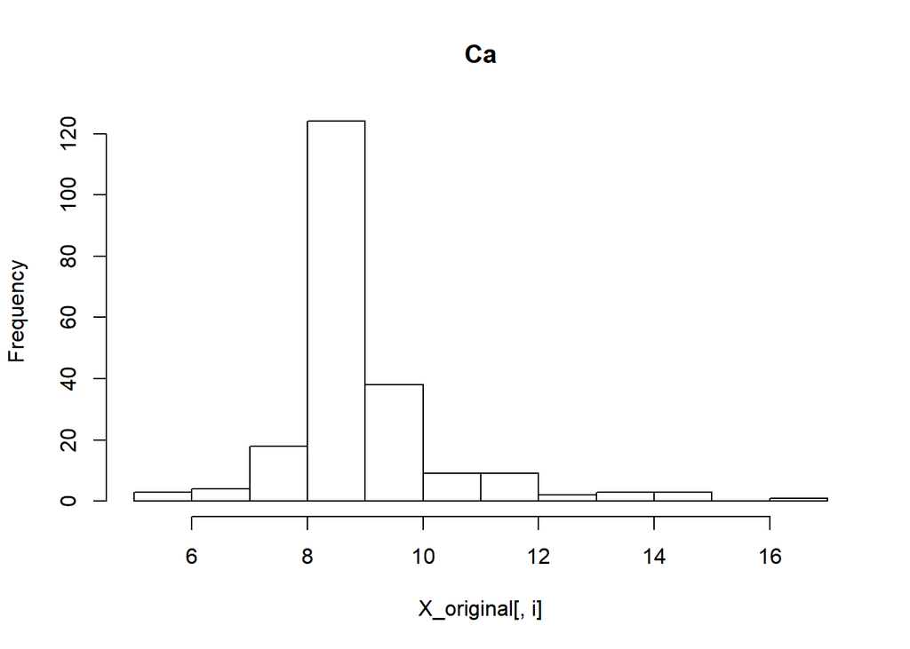

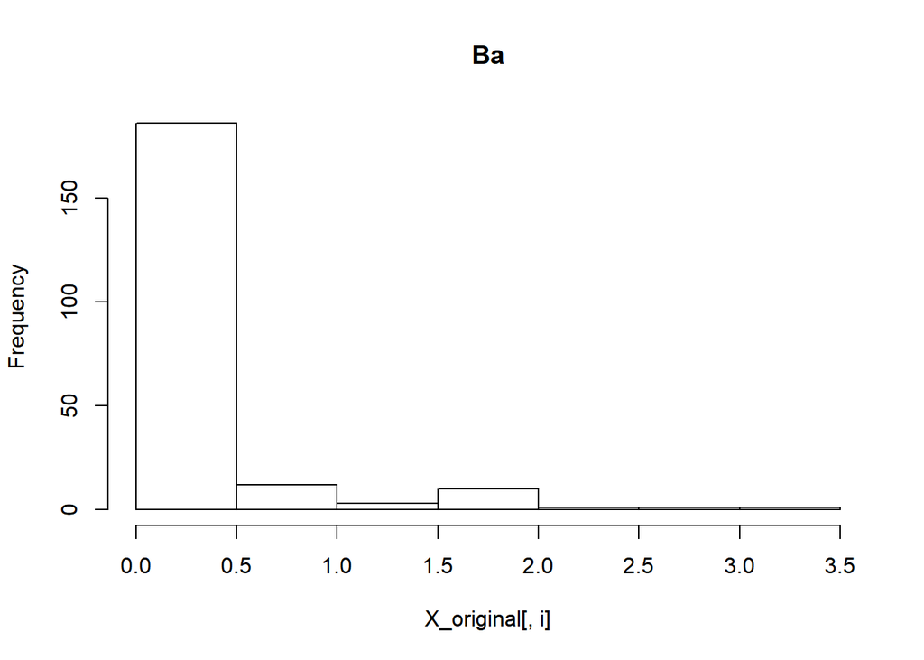

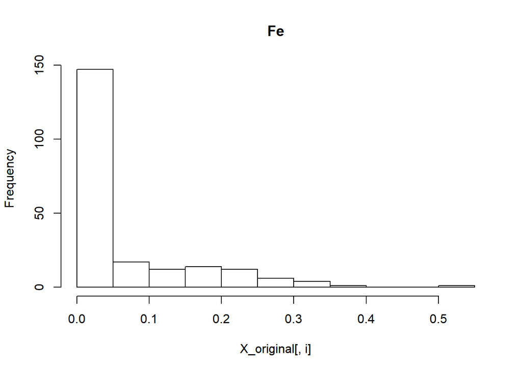

```r
# Histograms each attribute
# par(mfrow=c(dispRow,dispCol))
for(i in 1:totAttr) {
    hist(X_original[,i], main=names(X_original)[i])
}
```